# vgscKO fecundity analysis

```r
library(emmeans); packageVersion("emmeans")
```

```
## Caution: You lose important information if you filter this package's results.
## See '? untidy'

## [1] '2.0.1'
```

```r
library(glmmTMB); packageVersion("glmmTMB")
```

```
## [1] '1.1.14'
```

```r
library(MASS); packageVersion("MASS")
```

```
## [1] '7.3.65'
```

```r
library(arm); packageVersion("arm")
```

```
##
## arm (Version 1.14-4, built: 2024-4-1)

## Working directory is /Users/poppypescod/Library/CloudStorage/OneDrive-LSTM/FUNC GEN GROUP/vgsc gene drive lines/vgscKO/Coding

## [1] '1.14.4'
```

```r
library(DHARMa); packageVersion("DHARMa")
```

```
## [1] '0.4.7'
```

Loading data

```r
df <- read.csv("HatchData.csv")
head(df)
```

```
##   vgscKOParent Eggs Larvae Hatch Genotype
## 1         male  140    116  82.9   vgscKO
## 2         male   99     93  93.9       WT
## 3         male   96     20  20.8   vgscKO
## 4         male  137     90  65.7   vgscKO
## 5         male   82     77  93.9       WT
## 6         male   72     34  47.2       WT
```

Removing batches with fewer than 10 larvae

```r
df_clean <- na.omit(df)
df_clean <- subset(df_clean, Larvae > 10)

df_clean$Genotype <- factor(df_clean$Genotype, levels = c("WT", "vgscKO"))
df_clean$vgscKOParent <- factor(df_clean$vgscKOParent, levels = c("female", "male"))
```

### Egg laying

Negative binomial GLM to determine impact of Genotype and vgscKOParent on number of eggs laid

```r
m_eggs <- glm.nb(Eggs ~ Genotype * vgscKOParent, data = df_clean)
summary(m_eggs)
```

```
##
## Call:
## glm.nb(formula = Eggs ~ Genotype * vgscKOParent, data = df_clean,
##     init.theta = 10.73838928, link = log)
##
## Coefficients:
##                                 Estimate Std. Error z value Pr(>|z|)
## (Intercept)                      4.89622    0.06614  74.034  < 2e-16 ***
## GenotypevgscKO                  -0.18642    0.08589  -2.170 0.029978 *
## vgscKOParentmale                -0.36549    0.09429  -3.876 0.000106 ***
## GenotypevgscKO:vgscKOParentmale  0.32852    0.12584   2.611 0.009038 **
## ---
## Signif. codes:  0 '***' 0.001 '**' 0.01 '*' 0.05 '.' 0.1 ' ' 1
##
## (Dispersion parameter for Negative Binomial(10.7384) family taken to be 1)
##
##     Null deviance: 124.41  on 105  degrees of freedom
## Residual deviance: 108.92  on 102  degrees of freedom
## AIC: 1060.4
##
## Number of Fisher Scoring iterations: 1
##
##
##               Theta:  10.74
##           Std. Err.:  1.62
##
##  2 x log-likelihood:  -1050.37
```

```r
m_eggs_no_int <- glm.nb(Eggs ~ Genotype + vgscKOParent, data = df_clean)
anova(m_eggs_no_int, m_eggs, test = "Chisq")
```

```
## Likelihood ratio tests of Negative Binomial Models
##
## Response: Eggs
##                     Model    theta Resid. df    2 x log-lik.   Test    df
## 1 Genotype + vgscKOParent 10.02762       103       -1056.984
## 2 Genotype * vgscKOParent 10.73839       102       -1050.370 1 vs 2     1
##   LR stat.    Pr(Chi)
## 1
## 2 6.613771 0.01011932
```

Model with interaction term kept

Check for overdispersion

```r
dispersion_eggs <- sum(residuals(m_eggs, type = "pearson")^2) / df.residual(m_eggs)
dispersion_eggs
```

```
## [1] 0.8697583
```

Check residuals (should be <2 for good fit)

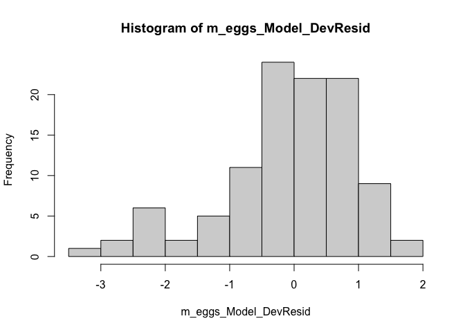

```r
m_eggs_Model_DevResid <- resid (m_eggs, type = "deviance")
hist(m_eggs_Model_DevResid)
```

Check variance of residuals across the range of fitted values (most points should fall within the grey line)

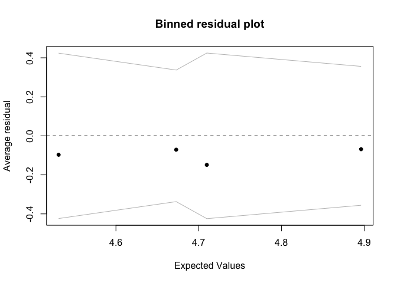

```r
m_eggs_Model_Predict <- predict(m_eggs)
binnedplot(m_eggs_Model_Predict, (m_eggs_Model_DevResid))
```

Check for outliers (Cook’s distance >1 indicates outliers)

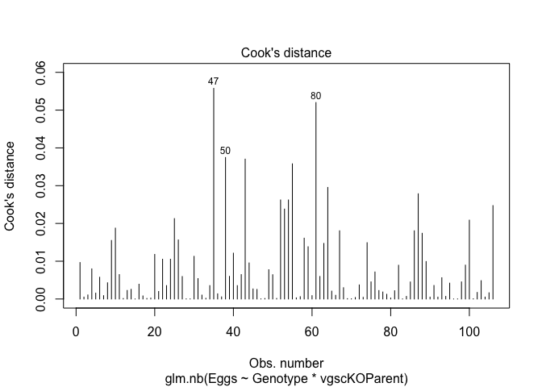

```r
plot(m_eggs, which = 4)
```

Impact of genotype on egg production

```r
pairs(emmeans(m_eggs, ~ Genotype, weights = "proportional"))
```

```
## NOTE: Results may be misleading due to involvement in interactions

##  contrast    estimate     SE  df z.ratio p.value
##  WT - vgscKO   0.0346 0.0628 Inf   0.550  0.5820
##
## Results are averaged over the levels of: vgscKOParent
## Results are given on the log (not the response) scale.
```

**Interpretation**

vgscKO females produce slightly larger egg batches than vgscKO males - but there is no overall impact of the vgscKO knock out on egg production.

### Larvae numbers

Negative binomial GLM for larvae numbers, with an offset factor for egg number.

```r
m_larvae_eff <- glm.nb(
  Larvae ~ Genotype * vgscKOParent + offset(log(Eggs)),
  data = df_clean
)
summary(m_larvae_eff)
```

```
##
## Call:
## glm.nb(formula = Larvae ~ Genotype * vgscKOParent + offset(log(Eggs)),
##     data = df_clean, init.theta = 11.99897303, link = log)
##
## Coefficients:
##                                 Estimate Std. Error z value Pr(>|z|)
## (Intercept)                     -0.32356    0.06407  -5.050 4.43e-07 ***
## GenotypevgscKO                  -0.02445    0.08360  -0.292    0.770
## vgscKOParentmale                -0.05265    0.09209  -0.572    0.567
## GenotypevgscKO:vgscKOParentmale  0.07732    0.12288   0.629    0.529
## ---
## Signif. codes:  0 '***' 0.001 '**' 0.01 '*' 0.05 '.' 0.1 ' ' 1
##
## (Dispersion parameter for Negative Binomial(11.999) family taken to be 1)
##
##     Null deviance: 109.22  on 105  degrees of freedom
## Residual deviance: 108.76  on 102  degrees of freedom
## AIC: 972.03
##
## Number of Fisher Scoring iterations: 1
##
##
##               Theta:  12.00
##           Std. Err.:  1.94
##
##  2 x log-likelihood:  -962.026
```

```r
dispersion_larvae <- sum(residuals(m_larvae_eff, type = "pearson")^2) / df.residual(m_larvae_eff)
dispersion_larvae
```

```
## [1] 0.8142196
```

Check residuals (should be <2 for good fit)

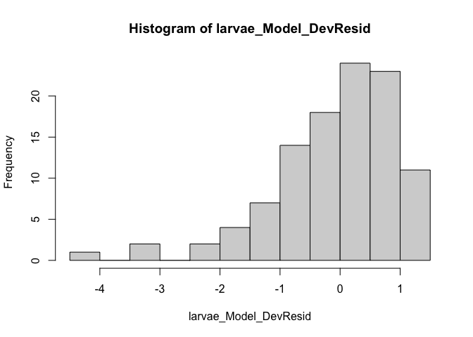

```r
larvae_Model_DevResid <- resid (m_larvae_eff, type = "deviance")
hist(larvae_Model_DevResid)
```

Slightly skewed but still relatively normal distribution around 0

Check variance of residuals across the range of fitted values (most points should fall within the grey line)

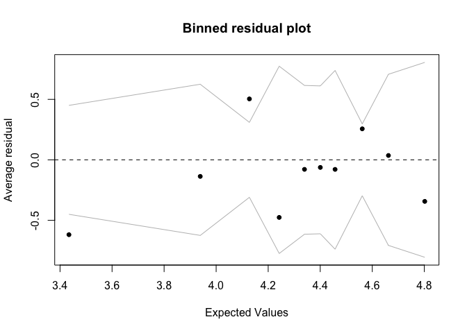

```r
larvae_Model_Predict <- predict(m_larvae_eff)
binnedplot(larvae_Model_Predict, (larvae_Model_DevResid))
```

Check for outliers (Cook’s distance >1 indicates outliers)

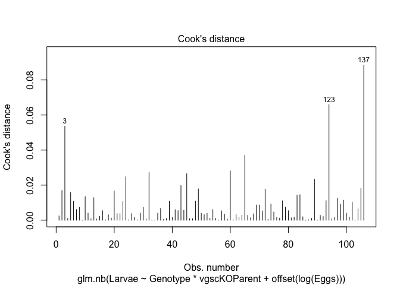

```r
plot(m_larvae_eff, which = 4)
```

Double-check with DHARMa

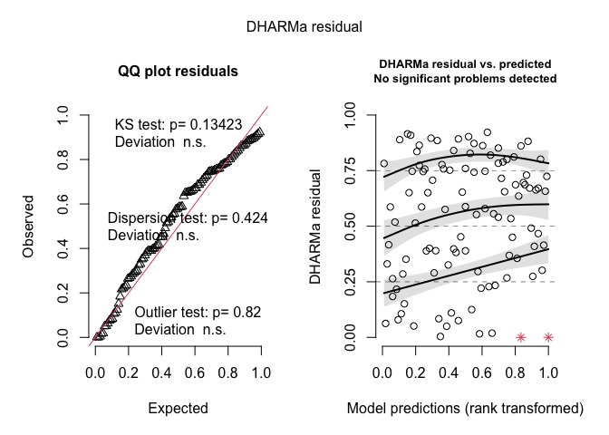

```r
sim <- simulateResiduals(m_larvae_eff)
plot(sim)
```

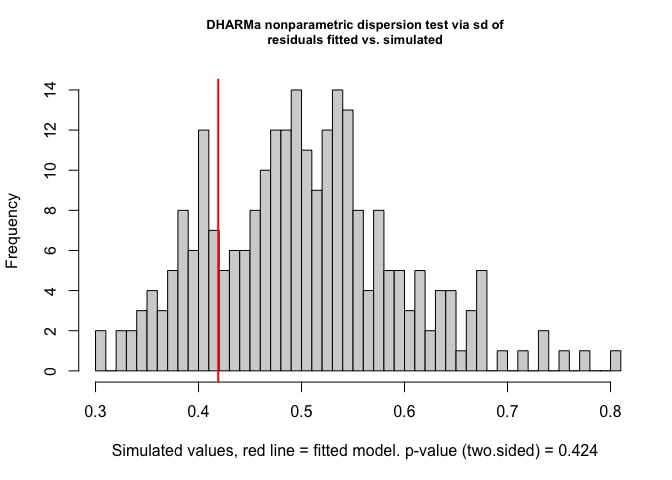

```
##
##  DHARMa nonparametric dispersion test via sd of residuals fitted vs.
##  simulated
##
## data:  simulationOutput
## dispersion = 0.83512, p-value = 0.424
## alternative hypothesis: two.sided
```

```r
testDispersion(sim)
```

Model fits well

Estimated marginal means

```r
pairs(emmeans(m_larvae_eff, ~ Genotype, type = "response"))
```

```
## NOTE: Results may be misleading due to involvement in interactions

##  contrast    ratio     SE  df null z.ratio p.value
##  WT / vgscKO 0.986 0.0606 Inf    1  -0.231  0.8171
##
## Results are averaged over the levels of: vgscKOParent
## Tests are performed on the log scale
```

```r
pairs(emmeans(m_larvae_eff, ~ vgscKOParent, type = "response"))
```

```
## NOTE: Results may be misleading due to involvement in interactions

##  contrast      ratio     SE  df null z.ratio p.value
##  female / male  1.01 0.0623 Inf    1   0.228  0.8199
##
## Results are averaged over the levels of: Genotype
## Tests are performed on the log scale
```

**Interpretation**

No significant impact of genotype or vgscKO parent on larval output.

### Hatch rate analysis

Quasibinomial GLM

```r
df_hatch <- subset(df_clean, Eggs > 0 & Larvae <= Eggs)

m_hatch_q <- glm(
  cbind(Larvae, Eggs - Larvae) ~ Genotype * vgscKOParent,
  family = quasibinomial,
  data = df_hatch
)
summary(m_hatch_q)
```

```
##
## Call:
## glm(formula = cbind(Larvae, Eggs - Larvae) ~ Genotype * vgscKOParent,
##     family = quasibinomial, data = df_hatch)
##
## Coefficients:
##                                 Estimate Std. Error t value Pr(>|t|)
## (Intercept)                      0.93410    0.18747   4.983 2.57e-06 ***
## GenotypevgscKO                  -0.06463    0.25104  -0.257    0.797
## vgscKOParentmale                -0.08122    0.29000  -0.280    0.780
## GenotypevgscKO:vgscKOParentmale  0.21577    0.38998   0.553    0.581
## ---
## Signif. codes:  0 '***' 0.001 '**' 0.01 '*' 0.05 '.' 0.1 ' ' 1
##
## (Dispersion parameter for quasibinomial family taken to be 21.90005)
##
##     Null deviance: 2383.8  on 105  degrees of freedom
## Residual deviance: 2375.9  on 102  degrees of freedom
## AIC: NA
##
## Number of Fisher Scoring iterations: 4
```

```r
dispersion_hatch <- sum(residuals(m_hatch_q, type = "pearson")^2) / df.residual(m_hatch_q)
dispersion_hatch
```

```
## [1] 21.89997
```

Dispersion far too high - try a beta-binomial model

```r
library(glmmTMB)
m_hatch_bb <- glmmTMB(
  cbind(Larvae, Eggs - Larvae) ~ Genotype * vgscKOParent,
  family = betabinomial(link = "logit"),
  data = df_hatch
)
summary(m_hatch_bb)
```

```
##  Family: betabinomial  ( logit )
## Formula:          cbind(Larvae, Eggs - Larvae) ~ Genotype * vgscKOParent
## Data: df_hatch
##
##       AIC       BIC    logLik -2*log(L)  df.resid
##     926.9     940.2    -458.4     916.9       101
##
##
## Dispersion parameter for betabinomial family (): 4.28
##
## Conditional model:
##                                 Estimate Std. Error z value Pr(>|z|)
## (Intercept)                       1.0789     0.2028   5.320 1.04e-07 ***
## GenotypevgscKO                   -0.2041     0.2567  -0.795    0.427
## vgscKOParentmale                 -0.3062     0.2772  -1.104    0.269
## GenotypevgscKO:vgscKOParentmale   0.3301     0.3676   0.898    0.369
## ---
## Signif. codes:  0 '***' 0.001 '**' 0.01 '*' 0.05 '.' 0.1 ' ' 1
```

**Check for model fit using DHARMa**

Overdispersion

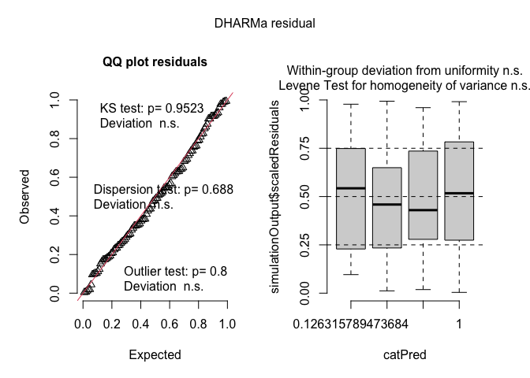

```r
sim <- simulateResiduals(m_hatch_bb)
plot(sim)
```

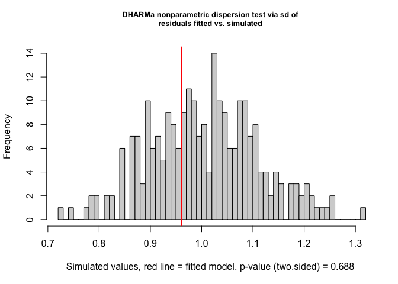

```
##
##  DHARMa nonparametric dispersion test via sd of residuals fitted vs.
##  simulated
##
## data:  simulationOutput
## dispersion = 0.95548, p-value = 0.688
## alternative hypothesis: two.sided
```

```r
testDispersion(sim)
```

Check for outliers

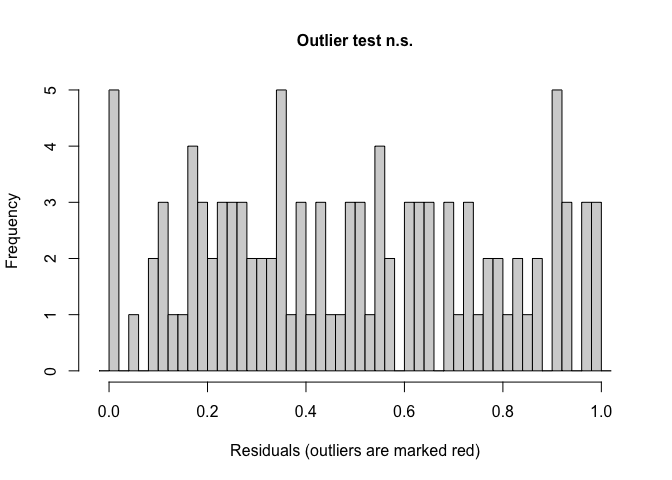

```
##
##  DHARMa bootstrapped outlier test
##
## data:  sim
## outliers at both margin(s) = 0, observations = 106, p-value = 0.72
## alternative hypothesis: two.sided
##  percent confidence interval:
##  0.00000000 0.02830189
## sample estimates:
## outlier frequency (expected: 0.00877358490566038 )
##                                                  0
```

```r
testOutliers(sim)
```

Beta-binomial model fits well

Overall (marginal) genotype effect:

```r
pairs(emmeans(m_hatch_bb, ~ Genotype, type = "response"))
```

```
## NOTE: Results may be misleading due to involvement in interactions

##  contrast    odds.ratio    SE  df null z.ratio p.value
##  WT / vgscKO       1.04 0.191 Inf    1   0.212  0.8318
##
## Results are averaged over the levels of: vgscKOParent
## Tests are performed on the log odds ratio scale
```

```r
pairs(emmeans(m_hatch_bb, ~ vgscKOParent, type = "response"))
```

```
## NOTE: Results may be misleading due to involvement in interactions

##  contrast      odds.ratio    SE  df null z.ratio p.value
##  female / male       1.15 0.212 Inf    1   0.768  0.4424
##
## Results are averaged over the levels of: Genotype
## Tests are performed on the log odds ratio scale
```

**Interpretation**

There was no significant effect of Genotype or vgscKO Parent sex on the hatch rate of eggs.